# [Project of Classification, Regression and Prediction]

[figure not shown]

### **Members of Group**

- 1. **BESSANH Isaac**
- 2. **COMLAN Yayra**
- 3. **GBODOGBE Zinsou René**

```r
knitr::opts_chunk$set(echo = TRUE)
```

## Importing packages

```r
library(readr)
library(tidyverse)
```

```r
library(ggplot2)
library(tidyverse)
library(gridExtra) ## for: grid.arrange
library(stargazer)
library(dplyr)
library(caret)
```

## Preliminaries: The site Traffic data

The data comes from a cooking recipe website. The company that owns the website wants to sell subscriptions, and the idea is that if the website receives a lot of visits (thus traffic is “high”) due to a posted recipe, the likelihood of a sale subscription increases.

So the overall goal of this project is to predict which recipes will lead to high traffic.

### Importing data

```r
Data <-read_csv("C:/Users/Users/Desktop/Projet_classification/recipe_site_traffic_2212.csv")%>%
  mutate_if(is.character, as.factor)
## Description de la base de données

glimpse(Data)
```

```
## Rows: 947
## Columns: 8
## $ recipe       <fct> 001, 002, 003, 004, 005, 006, 007, 008, 009, 010, 011, 01…
## $ calories     <dbl> NA, 35.48, 914.28, 97.03, 27.05, 691.15, 183.94, 299.14, …
## $ carbohydrate <dbl> NA, 38.56, 42.68, 30.56, 1.85, 3.46, 47.95, 3.17, 3.78, 4…
## $ sugar        <dbl> NA, 0.66, 3.09, 38.63, 0.80, 1.65, 9.75, 0.40, 3.37, 3.99…
## $ protein      <dbl> NA, 0.92, 2.88, 0.02, 0.53, 53.93, 46.71, 32.40, 3.79, 11…
## $ category     <fct> Pork, Potato, Breakfast, Beverages, Beverages, One Dish M…
## $ servings     <fct> 6, 4, 1, 4, 4, 2, 4, 4, 6, 2, 1, 6, 4, 4, 4, 6, 2, 1, 6, …
## $ high_traffic <fct> High, High, NA, High, NA, High, NA, NA, High, NA, NA, NA,…
```

As shown in the results above, our database is described on 947 recipes with eight (08) characterizing the latter. Below is the complete description of each of these variables.

| Variable | Explication |
| --- | --- |
| recette | Identificateur unique de la recette |
| Calories | nombre de calories |
| glucide | Quantité de glucides en grammes |
| sucre | Quantité de sucre en grammes |
| protéine | Quantité de protéines en grammes |
| catégorie | type de recette. Les recettes sont répertoriées dans l'une des dix regroupements possibles (Déjeuner/Collations, 'Boissons', 'Patate', 'Légume', 'Viande', 'Poulet', 'Porc', 'Dessert', 'Petit déjeuner'… |
| Portions | Nombre de portions pour la recette |
| high_traffic | si le trafic sur le site était élevé lorsque cette recette a été montré, il est marqué par « High ». |

## Data processing

In this section we will be required to clean our database for effective analysis. This will specifically involve recoding the variables, presenting the proportion of missing values for each variable and moving on to their processing if possible.

## 1-Recoding of variables and checking the validity of the data.

## a- Recoding of the high-traffic variable and its validity.

```r
## Structure display

str(Data$high_traffic)
```

```
##  Factor w/ 1 level "High": 1 1 NA 1 NA 1 NA NA 1 NA ...
```

We note that the variable high-traffic has the modality 1 for all the recipes presenting a traffic package and NA for all the others. From the context of our study, we notice that when a recipe is visited more often it is marked *High* and therefore nothing (NA) when it is not. Therefore, we will assign the numerical code 0 for all recipes presenting NA, this means that these recipes have low traffic.

```r
Data$trafic_recod<-ifelse(is.na(Data$high_traffic), 0, 1)
str(Data$trafic_recod)
```

```
##  num [1:947] 1 1 0 1 0 1 0 0 1 0 ...
```

Analysis of our new variable “trafic_recod” reveals that it is a binary numeric variable, taking the value 1 for high traffic recipes and 0 for others. This binary structure is particularly suited to our analysis objectives, in particular for the application of the different models planned (Linear Probability Model, Logit Model and Random Forest Model). Indeed, these models require a binary dependent variable, which fully justifies the validity of our recoded variable “trafic_recod” which is our new response variable.

**Remark**: 1=High,0=Lower

## b- Missing values.

```r
Data %>%
  summarise(across(-high_traffic, ~ mean(is.na(.x)))) %>%
  dplyr::select(dplyr::where(~ .x > 0))
```

```
## # A tibble: 1 × 4
##   calories carbohydrate  sugar protein
##      <dbl>        <dbl>  <dbl>   <dbl>
## 1   0.0549       0.0549 0.0549  0.0549
```

The calories, carbohydrate, sugar and protein variables have the same number of missing values, i.e. 5.49% of missing values, and those for the same recipes. In this case we can delete observations with missing values in the database for the following reasons. First, we have a small number of observations with missing values (52 observations out of 947) or 5.49%. By deleting them we will still keep 895 observations which is more than enough to train the different models and will less affect the statistical power of our analyzes as well as our results. Second, the fact that the missing values are for the same observations suggests that these are probably recipes for which this nutritional information was not provided. Thus, their deletion is safer in this case. Third, imputations can introduce bias into our analyses.

```r
# Delete observations with missing values.
Data <- Data[!is.na(Data$calories) & !is.na(Data$protein)& !is.na(Data$sugar)& !is.na(Data$carbohydrate), ]

# Show number of observations after cleaning
print(nrow(Data))
```

```
## [1] 895
```

From this result, we realize that there is no more missing data in the database. Thus, the database is clean and can be analyzed.

## 2- Exploratory Data Analysis (EDA)

Before rigorously embarking on the implementation of the different models, we will explore the relationships between our variable of interest (traffic_recod) and the other variables in the database.

```r
Data %>%
  count(trafic_recod) %>%
  mutate(prop = n/sum(n))
```

```
## # A tibble: 2 × 3
##   trafic_recod     n  prop
##          <dbl> <int> <dbl>
## 1            0   360 0.402
## 2            1   535 0.598
```

The analysis of these results shows that more than half of the revenues (59.77%) present strong traffic.

## a-Grouping by category of recipes with high traffic.

```r
Data %>%
    group_by(category) %>%
    summarise(mean_trafic = mean(trafic_recod))
```

```
## # A tibble: 11 × 2
##    category       mean_trafic
##    <fct>                <dbl>
##  1 Beverages           0.0543
##  2 Breakfast           0.311
##  3 Chicken             0.362
##  4 Chicken Breast      0.468
##  5 Dessert             0.623
##  6 Lunch/Snacks        0.634
##  7 Meat                0.757
##  8 One Dish Meal       0.761
##  9 Pork                0.904
## 10 Potato              0.940
## 11 Vegetable           0.987
```

The *Potato (0.9398)*, *vegetable(0.9871)* and *Pork (0.9041)* categories have the highest average traffic, suggesting that they are the most popular or most visited. The *Beverages (0.0543)* and *Breakfast (0.3113)* categories have the lowest average traffic, which shows a lower interest for these types of revenue. The other categories (ex. : Chicken, Dessert, Lunch/Snacks, etc.) have varied average traffic, lying between these two extremes.

## b-Grouping by category and by portion of recipes with high traffic.

```r
Data %>%
    group_by(category,servings) %>%
    summarise(mean_trafic = mean(trafic_recod))
```

```
## # A tibble: 46 × 3
## # Groups:   category [11]
##    category  servings mean_trafic
##    <fct>     <fct>          <dbl>
##  1 Beverages 1             0.05
##  2 Beverages 2             0.0588
##  3 Beverages 4             0.0294
##  4 Beverages 6             0.0952
##  5 Breakfast 1             0.346
##  6 Breakfast 2             0.333
##  7 Breakfast 4             0.220
##  8 Breakfast 6             0.444
##  9 Chicken   1             0.467
## 10 Chicken   2             0.231
## # ℹ 36 more rows
```

## c-Data visualization.

### Visualization of traffic by revenue categories.

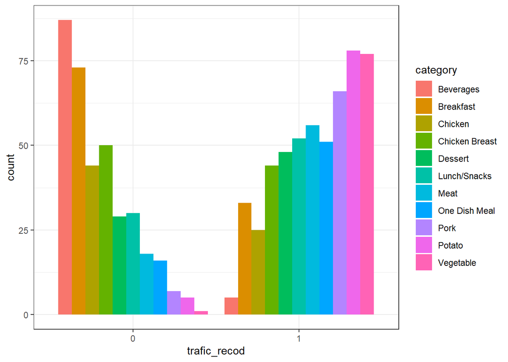

```r
# counts by categories of recipes
p1 <- ggplot(Data %>% mutate(trafic_recod = factor(trafic_recod))) +
    geom_bar(aes(x=trafic_recod, fill=category), position="dodge") +
    theme_bw()
grid.arrange(p1,nrow=1)
```

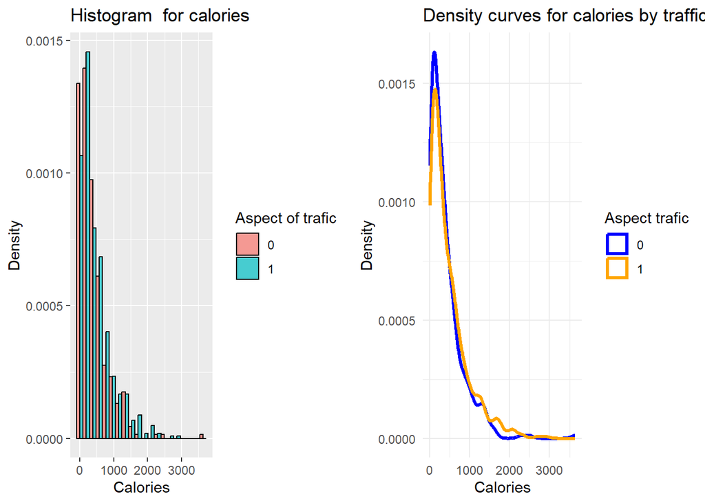

```r
#Histogram of quantitative covariates
## for calories

p1<- ggplot(Data, aes(x = calories, fill = factor(trafic_recod))) +
  # Histogram
 geom_histogram(aes(y = ..density..), position = "dodge", bins = 20, alpha = 0.7, color = "black") +labs(
    title = "Histogram  for calories",
    x = "Calories",
    y = "Density",
    fill = "Aspect of trafic",
    color = "Aspect of trafic "
  )

  # Courbe de densité seule (p2)
p2 <- ggplot(Data, aes(x = calories, color = factor(trafic_recod))) +
  geom_density(size = 1.2) +
  scale_color_manual(values = c("blue", "orange"), name = "Aspect trafic") +
  labs(
    title = "Density curves for calories by traffic categories",
    x = "Calories",
    y = "Density"
  ) +
  theme_minimal()
# Combination of the two graphs
grid.arrange(p1, p2, ncol = 2) # ncol = 2 pour les afficher côte à côte
```

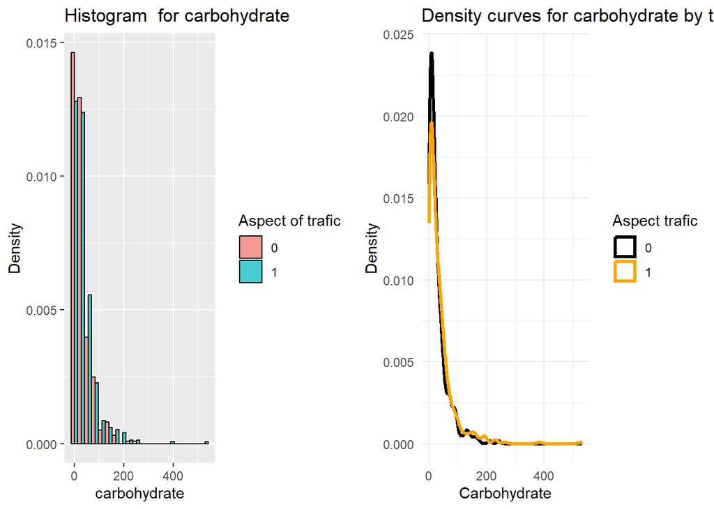

```r
#Histogram for carbohydrate

p1<- ggplot(Data, aes(x = carbohydrate, fill = factor(trafic_recod))) +
  # Histogram
 geom_histogram(aes(y = ..density..), position = "dodge", bins = 20, alpha = 0.7, color = "black") +labs(
    title = "Histogram  for carbohydrate",
    x = "carbohydrate",
    y = "Density",
    fill = "Aspect of trafic",
    color = "Aspect of trafic "
  )

  # Courbe de densité seule (p2)
p2 <- ggplot(Data, aes(x = carbohydrate, color = factor(trafic_recod))) +
  geom_density(size = 1.2) +
  scale_color_manual(values = c("black", "orange"), name = "Aspect trafic") +
  labs(
    title = "Density curves for carbohydrate by traffic categories",
    x = "Carbohydrate",
    y = "Density"
  ) +
  theme_minimal()

# Combination of the two graphs
grid.arrange(p1, p2, ncol = 2) # ncol = 2 pour les afficher côte à côte
```

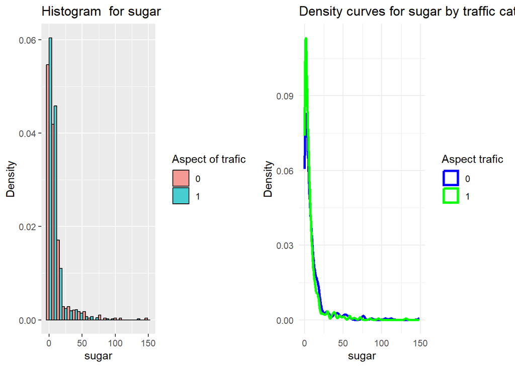

```r
#Histogram for sugar
p1<- ggplot(Data, aes(x = sugar, fill = factor(trafic_recod))) +
  # Histogram
 geom_histogram(aes(y = ..density..), position = "dodge", bins = 20, alpha = 0.7, color = "black") +labs(
    title = "Histogram  for sugar",
    x = "sugar",
    y = "Density",
    fill = "Aspect of trafic",
    color = "Aspect of trafic "
  )

  # density curve  (p2)
p2 <- ggplot(Data, aes(x = sugar, color = factor(trafic_recod))) +
  geom_density(size = 1.2) +
  scale_color_manual(values = c("blue", "green"), name = "Aspect trafic") +
  labs(
    title = "Density curves for sugar by traffic categories",
    x = "sugar",
    y = "Density"
  ) +
  theme_minimal()

# Combination of the two graphs
grid.arrange(p1, p2, ncol = 2) # ncol = 2 pour les afficher côte à côte
```

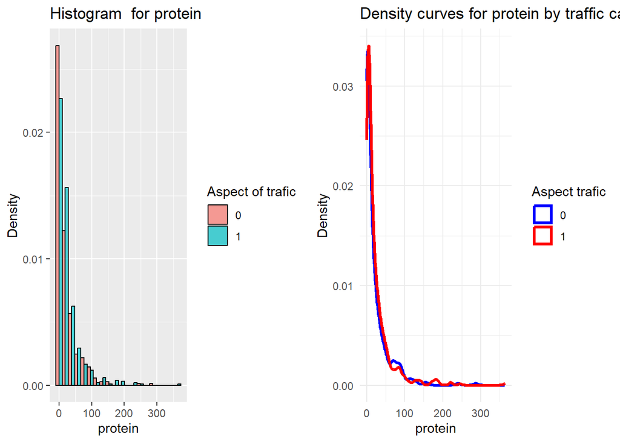

```r
#Histogram for protein
p1<- ggplot(Data, aes(x = protein, fill = factor(trafic_recod))) +
  # Histogram
 geom_histogram(aes(y = ..density..), position = "dodge", bins = 20, alpha = 0.7, color = "black") +labs(
    title = "Histogram  for protein",
    x = "protein",
    y = "Density",
    fill = "Aspect of trafic",
    color = "Aspect of trafic "
  )

  # density curve  (p2)
p2 <- ggplot(Data, aes(x = protein, color = factor(trafic_recod))) +
  geom_density(size = 1.2) +
  scale_color_manual(values = c("blue", "red"), name = "Aspect trafic") +
  labs(
    title = "Density curves for protein by traffic categories",
    x = "protein",
    y = "Density"
  ) +
  theme_minimal()

# Combination of the two graphs
grid.arrange(p1, p2, ncol = 2) # ncol = 2 pour les afficher côte à côte
```

In general, all the quantitative variables( calories,carbohydrate,sugar,protein) are’nt normaly distributed given for each modalitie of trafic aspect.

## d-Visualization of traffic by revenue portions.

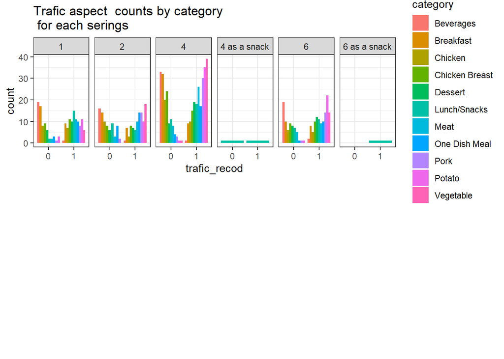

```r
## percentages by servings   and trafic_recod
p2 <- ggplot(Data%>% mutate(trafic_recod = factor(trafic_recod)), aes(x=trafic_recod, fill=category)) +
    geom_bar(position="dodge") +
    facet_grid(~ servings) +
    labs(title="Trafic aspect  counts by category \n for each serings") +
    theme_bw()
grid.arrange(p2, nrow=2)
```

In the analyzes above the recipe of the categories *Vegetable*, *Potato*, *Pork* and *one Dish Meal* are the most visited on the company’s website. But, the results of the graph show that portion 4 without snack of these recipes is more visited by customers as portions 4 with snack and 6 with snack have the least proportions of traffic whatever the categories of recipes. This can mean that Customers don’t really like to visit the snack recipe categories.

## 3-Division of the database into test data and training data.

This section consists of dividing our database into test data and training data in order to evaluate the predictability performance of our model. For this, we will put 60% of the observations in the training base and the remaining 40% in the test data.

```r
set.seed(2453)
tr <- sample(nrow(Data), round(nrow(Data) * 0.6)) ## 60/40 split train/test
my_train <- Data[tr, ]
my_test  <- Data[-tr, ]
```

## 4-

## a-Estimation of Models LPM and logit

```r
# LPM model

modf1 <- trafic_recod~ category + calories + protein + sugar+ carbohydrate + servings

lm.fit1 <- lm(modf1 , data=my_train)

# Logit model

modf2 <- trafic_recod~ category + calories + protein + sugar+ carbohydrate + servings

lm.fit2 <-  glm(modf2 , family="binomial",data=my_train)

stargazer(lm.fit1,lm.fit2,
          dep.var.caption="",dep.var.labels="",
          omit.table.layout = "n", star.cutoffs = NA,no.space=TRUE,
          keep.stat=c("rsq","n"),
          header=FALSE,
          column.labels=c("LPM ", "LOGIT"),
          title="Aspect of trafic", type="text"
          )
```

```
##
## Aspect of trafic
## ==========================================
##
##                           OLS    logistic
##                           LPM      LOGIT
##                           (1)       (2)
## ------------------------------------------
## categoryBreakfast        0.240     1.954
##                         (0.077)   (0.665)
## categoryChicken          0.332     2.366
##                         (0.090)   (0.700)
## categoryChicken Breast   0.417     2.727
##                         (0.082)   (0.675)
## categoryDessert          0.652     3.736
##                         (0.088)   (0.715)
## categoryLunch/Snacks     0.699     3.971
##                         (0.083)   (0.698)
## categoryMeat             0.640     3.680
##                         (0.085)   (0.695)
## categoryOne Dish Meal    0.688     3.908
##                         (0.092)   (0.734)
## categoryPork             0.851     5.188
##                         (0.095)   (0.877)
## categoryPotato           0.841     5.182
##                         (0.083)   (0.804)
## categoryVegetable        0.911     6.577
##                         (0.083)   (1.177)
## calories               -0.00003   -0.0002
##                        (0.00004) (0.0002)
## protein                 0.0003     0.002
##                         (0.001)   (0.004)
## sugar                   -0.001    -0.007
##                         (0.002)   (0.009)
## carbohydrate            0.0003     0.003
##                        (0.0004)   (0.003)
## servings2                0.015     0.087
##                         (0.058)   (0.366)
## servings4               -0.009    -0.063
##                         (0.048)   (0.293)
## servings4 as a snack    -0.242    -1.055
##                         (0.295)   (1.477)
## servings6                0.026     0.163
##                         (0.056)   (0.349)
## servings6 as a snack     0.265    12.556
##                         (0.412)  (535.411)
## Constant                 0.067    -2.801
##                         (0.067)   (0.638)
## ------------------------------------------
## Observations              537       537
## R2                       0.338
## ==========================================
```

## Marginal effects for logit model

```r
#Marginal effects for the logit model
me_logit_atmean <- mfx::logitmfx(lm.fit2, data=my_train, atmean = TRUE)
me_logit_atmean
```

```
## Call:
## mfx::logitmfx(formula = lm.fit2, data = my_train, atmean = TRUE)
##
## Marginal Effects:
##                              dF/dx   Std. Err.       z   P>|z|
## categoryBreakfast       3.0775e-01  1.7708e-01  1.7379 0.08224 .
## categoryChicken         3.2594e-01  1.9289e-01  1.6898 0.09106 .
## categoryChicken Breast  3.7154e-01  2.0866e-01  1.7806 0.07499 .
## categoryDessert         3.9821e-01  2.3048e-01  1.7278 0.08403 .
## categoryLunch/Snacks    4.1309e-01  2.3490e-01  1.7585 0.07865 .
## categoryMeat            4.0392e-01  2.3051e-01  1.7523 0.07973 .
## categoryOne Dish Meal   3.9088e-01  2.3104e-01  1.6918 0.09069 .
## categoryPork            4.1523e-01  2.4211e-01  1.7150 0.08634 .
## categoryPotato          4.5478e-01  2.4679e-01  1.8428 0.06536 .
## categoryVegetable       4.7057e-01  2.5007e-01  1.8817 0.05987 .
## calories               -3.9702e-05  5.3564e-05 -0.7412 0.45857
## protein                 3.7622e-04  8.4957e-04  0.4428 0.65788
## sugar                  -1.5343e-03  2.0344e-03 -0.7541 0.45077
## carbohydrate            6.0999e-04  6.3150e-04  0.9659 0.33408
## servings2               1.9306e-02  8.0790e-02  0.2390 0.81113
## servings4              -1.4198e-02  6.6131e-02 -0.2147 0.83001
## servings4 as a snack   -2.5659e-01  3.5608e-01 -0.7206 0.47115
## servings6               3.5935e-02  7.6573e-02  0.4693 0.63886
## servings6 as a snack    3.4510e-01  3.2653e-02 10.5686 < 2e-16 ***
## ---
## Signif. codes:  0 '***' 0.001 '**' 0.01 '*' 0.05 '.' 0.1 ' ' 1
##
## dF/dx is for discrete change for the following variables:
##
##  [1] "categoryBreakfast"      "categoryChicken"        "categoryChicken Breast"
##  [4] "categoryDessert"        "categoryLunch/Snacks"   "categoryMeat"
##  [7] "categoryOne Dish Meal"  "categoryPork"           "categoryPotato"
## [10] "categoryVegetable"      "servings2"              "servings4"
## [13] "servings4 as a snack"   "servings6"              "servings6 as a snack"
```

## b- Comparison of marginal effects for two models

```r
me_logit_average <- mfx::logitmfx(lm.fit2, data=my_train, atmean = FALSE)
ME<-cbind(me_logit_atmean$mfxest[,"dF/dx"],
          me_logit_average$mfxest[,"dF/dx"],
          coefficients(lm.fit2)[-1])
colnames(ME)<- c("ref person", "average","LPM coeff")
print(ME, digits=3)
```

```
##                        ref person   average LPM coeff
## categoryBreakfast        3.08e-01  2.18e-01  1.953657
## categoryChicken          3.26e-01  2.62e-01  2.366162
## categoryChicken Breast   3.72e-01  2.93e-01  2.727280
## categoryDessert          3.98e-01  3.74e-01  3.735893
## categoryLunch/Snacks     4.13e-01  3.94e-01  3.970579
## categoryMeat             4.04e-01  3.77e-01  3.679784
## categoryOne Dish Meal    3.91e-01  3.83e-01  3.907940
## categoryPork             4.15e-01  4.27e-01  5.187866
## categoryPotato           4.55e-01  4.52e-01  5.182113
## categoryVegetable        4.71e-01  4.61e-01  6.576955
## calories                -3.97e-05 -2.78e-05 -0.000177
## protein                  3.76e-04  2.64e-04  0.001677
## sugar                   -1.53e-03 -1.08e-03 -0.006839
## carbohydrate             6.10e-04  4.28e-04  0.002719
## servings2                1.93e-02  1.36e-02  0.086869
## servings4               -1.42e-02 -9.95e-03 -0.063203
## servings4 as a snack    -2.57e-01 -1.72e-01 -1.054900
## servings6                3.59e-02  2.54e-02  0.162923
## servings6 as a snack     3.45e-01  3.90e-01 12.556017
```

We remark that the marginal effects for the two models are not the same.

## c- The Variable Score for each model

In machine learning, one way to interpret the model is to calculate variable importance scores (Varimps). These often depend on the method used for the estimation. In a regression context, this is simply the value of the t statistic. We can plot them as bar charts:

```r
# Model LPM

# variable importance: t-statistic
temp <- summary(lm.fit1) # get t-statistic

varimp1 <- tibble(variable=rownames(temp$coefficients[-1,]), # drop Intercept
                 score =temp$coefficients[-1,3]) %>%
          arrange(desc(abs(score))) %>%
          # set levels as otherwise factors generated alphabetically in ggplot
          mutate(variable=factor(variable, levels=variable[order(abs(score))]))
varimp1
```

```
## # A tibble: 19 × 2
##    variable                score
##    <fct>                   <dbl>
##  1 categoryVegetable      11.0
##  2 categoryPotato         10.1
##  3 categoryPork            8.94
##  4 categoryLunch/Snacks    8.40
##  5 categoryMeat            7.50
##  6 categoryOne Dish Meal   7.49
##  7 categoryDessert         7.40
##  8 categoryChicken Breast  5.06
##  9 categoryChicken         3.70
## 10 categoryBreakfast       3.11
## 11 carbohydrate            0.934
## 12 servings4 as a snack   -0.820
## 13 sugar                  -0.788
## 14 calories               -0.776
## 15 servings6 as a snack    0.643
## 16 protein                 0.482
## 17 servings6               0.460
## 18 servings2               0.257
## 19 servings4              -0.199
```

```r
# For  LOGIT model

# variable importance: t-statistic
temp <- summary(lm.fit2) # get t-statistic

varimp2 <- tibble(variable=rownames(temp$coefficients[-1,]), # drop Intercept
                 score =temp$coefficients[-1,3]) %>%
          arrange(desc(abs(score))) %>%
          # set levels as otherwise factors generated alphabetically in ggplot
          mutate(variable=factor(variable, levels=variable[order(abs(score))]))
varimp2
```

```
## # A tibble: 19 × 2
##    variable                 score
##    <fct>                    <dbl>
##  1 categoryPotato          6.45
##  2 categoryPork            5.92
##  3 categoryLunch/Snacks    5.69
##  4 categoryVegetable       5.59
##  5 categoryOne Dish Meal   5.32
##  6 categoryMeat            5.29
##  7 categoryDessert         5.22
##  8 categoryChicken Breast  4.04
##  9 categoryChicken         3.38
## 10 categoryBreakfast       2.94
## 11 carbohydrate            1.01
## 12 sugar                  -0.777
## 13 calories               -0.763
## 14 servings4 as a snack   -0.714
## 15 servings6               0.467
## 16 protein                 0.447
## 17 servings2               0.237
## 18 servings4              -0.215
## 19 servings6 as a snack    0.0235
```

## d-Graphic of Score

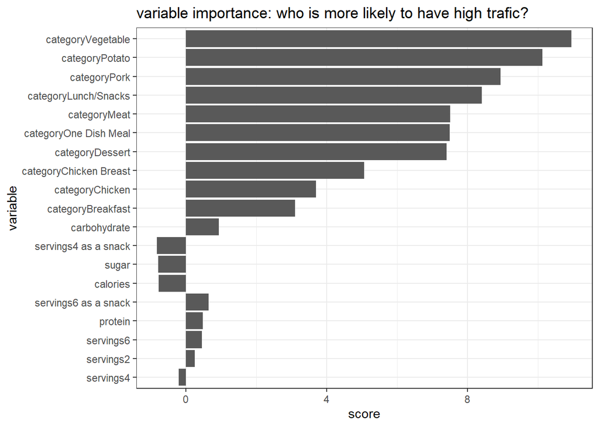

```r
# For LPM model

ggplot(varimp1, aes(x=variable, y=score )) +
    geom_col() +
    coord_flip() +
    theme_bw() +
    ggtitle("variable importance: who is more likely to have high trafic?")
```

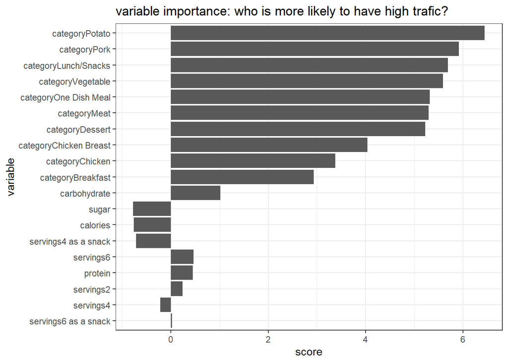

```r
# For  LOGIT model

ggplot(varimp2, aes(x=variable, y=score )) +
    geom_col() +
    coord_flip() +
    theme_bw() +
    ggtitle("variable importance: who is more likely to have high trafic?")
```

## 5-Random Forest model estimation

```r
# Determination of the optimal number of branches

# Basic model
modf3 <- trafic_recod~ category + calories + protein + sugar+ carbohydrate + servings

# Setting up cross-validation
control <- trainControl(
    method = "cv",         # Cross-validation
    number = 10,            # Number of folds
    search = "grid",         # Search by grid
    verboseIter = TRUE         # Show progress
)

# Create a grid of mtry values to test
# For this example, we test 2 to 6 predictors
# Adjust these values according to your total number of variables
myGrid <- expand.grid(
    mtry = 2:6,
    min.node.size = 1,     # Minimum leaf node size
    splitrule = "variance" # Split rule for regression
)

# Training the model with different mtry values
rf_tune <- train(
    modf3,            # Model
    data = my_train,  #   training data
    method = "ranger",
    metric = "RMSE",       # Evaluation metrics (RMSE for regression, Accuracy for classification)
    trControl = control,
    tuneGrid = myGrid,
    importance = "impurity",

)
print(print(rf_tune))
```

```
## Random Forest
##
## 537 samples
##   6 predictor
##
## No pre-processing
## Resampling: Cross-Validated (10 fold)
## Summary of sample sizes: 484, 484, 483, 483, 483, 483, ...
## Resampling results across tuning parameters:
##
##   mtry  RMSE       Rsquared   MAE
##   2     0.4357044  0.2314541  0.4027909
##   3     0.4301848  0.2358063  0.3807978
##   4     0.4323548  0.2249822  0.3749319
##   5     0.4355035  0.2149330  0.3731042
##   6     0.4371752  0.2105355  0.3724443
##
## Tuning parameter 'splitrule' was held constant at a value of variance
##
## Tuning parameter 'min.node.size' was held constant at a value of 1
## RMSE was used to select the optimal model using the smallest value.
## The final values used for the model were mtry = 3, splitrule = variance
##  and min.node.size = 1.
##  mtry RMSE        Rsquared    MAE
##  "2"  "0.4357044" "0.2314541" "0.4027909"
##  "3"  "0.4301848" "0.2358063" "0.3807978"
##  "4"  "0.4323548" "0.2249822" "0.3749319"
##  "5"  "0.4355035" "0.2149330" "0.3731042"
##  "6"  "0.4371752" "0.2105355" "0.3724443"
```

## Data Visualization

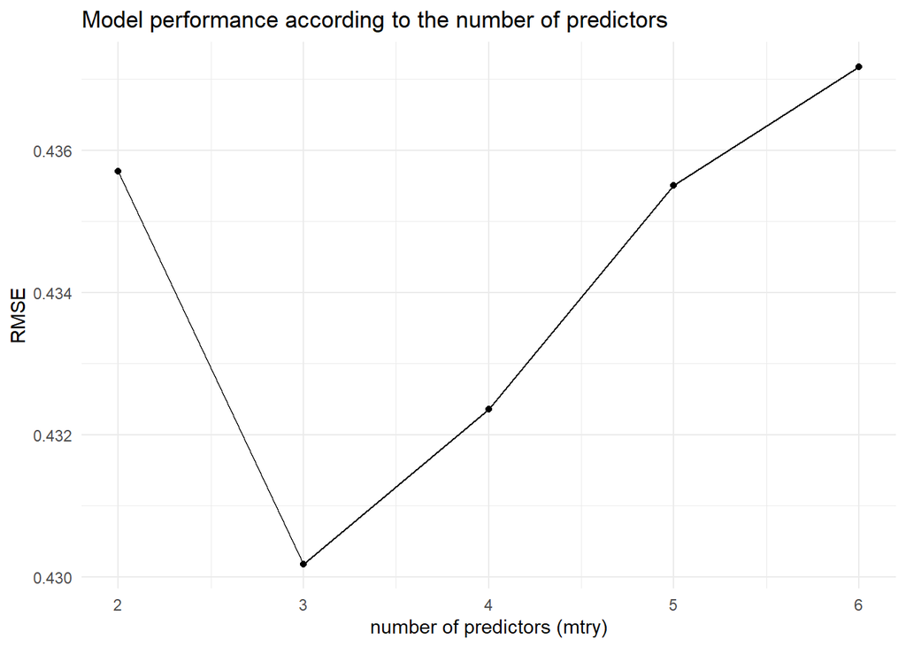

```r
# Visualization of results
ggplot(rf_tune) +
    geom_line() +
    geom_point() +
    xlab("number of predictors (mtry)") +
    ylab("RMSE") +
    ggtitle("Model performance according to the number of predictors") +
    theme_minimal()
```

## The optimal number of predictors.

```r
# Obtain the best  value of mtry
best_mtry <- rf_tune$bestTune$mtry
cat("The optimal number of predictors. (mtry) is:", best_mtry)
```

```
## The optimal number of predictors. (mtry) is: 3
```

The results below show that based on the RMSE (Residual Mean Square Error) we realize that by using three regressors in our random forest model we can optimize its predictability power.

## Random Forest model

```r
## fit the best RF model (in terms of CV performance) to train data
set.seed(345)

rf.fit3 <- ranger::ranger(modf3, data=my_train, mtry=rf_tune$bestTune$mtry,
                  importance="impurity", probability = TRUE)

print(rf.fit3)
```

```
## Ranger result
##
## Call:
##  ranger::ranger(modf3, data = my_train, mtry = rf_tune$bestTune$mtry,      importance = "impurity", probability = TRUE)
##
## Type:                             Probability estimation
## Number of trees:                  500
## Sample size:                      537
## Number of independent variables:  6
## Mtry:                             3
## Target node size:                 10
## Variable importance mode:         impurity
## Splitrule:                        gini
## OOB prediction error (Brier s.):  0.1756401
```

## Variable importance score .

```r
varimp <- tibble(Variable=names(rf.fit3$variable.importance),
                 Importance = rf.fit3$variable.importance) %>%
    arrange(desc(Importance)) %>%
    mutate(Variable=factor(Variable, levels=Variable[order(Importance)]))
print(varimp)
```

```
## # A tibble: 6 × 2
##   Variable     Importance
##   <fct>             <dbl>
## 1 category          75.6
## 2 protein           38.5
## 3 calories          31.6
## 4 sugar             30.6
## 5 carbohydrate      24.7
## 6 servings           6.20
```

## Score graph

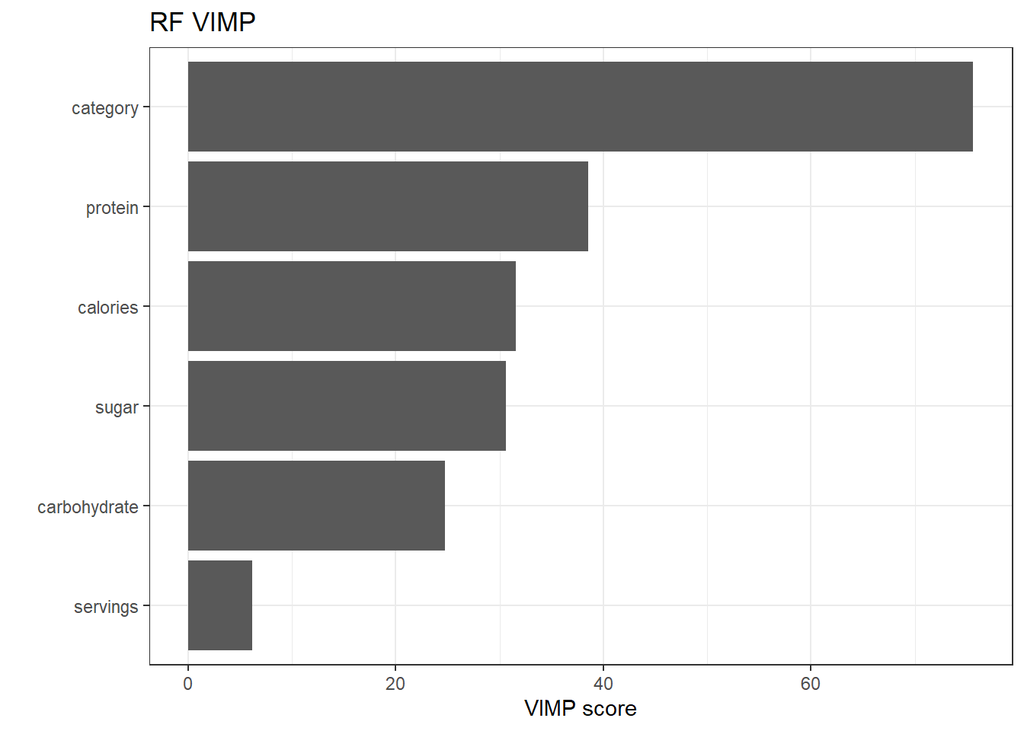

```r
ggplot(varimp,aes(reorder(Variable, Importance), Importance)) +
  geom_col() +
  coord_flip() +
  labs(x="", y="VIMP score" , title="RF VIMP") +
  theme_bw()
```

This graph shows that the *category* variable is the most important to the model, followed by *protein*, which also contributes significantly. The variables *calories, sugar, and carbohydrate* are of moderate importance. On the other hand, *servings* has a very weak contribution and little influence on the predictions. This suggests that the former variables should be prioritized in the analysis, while the latter might be less relevant.

## 6- Prediction of revenue traffic aspect and determination of the confusion factor of each model.

To evaluate the performance of the different models based on the confusion matrices, we will use the following matrices.

## Metric evaluation of accuracy

[output not shown]

### Legend :

- VP = True positive
- VN = True Negative
- FP = False positive
- FN = False Negative

### LPM model

```r
predict1<-predict(lm.fit1,newdata=my_test)
class_lpm <- ifelse(predict1 > 0.5, 1, 0)
# Confusion_matrix
matrix1<-table(factor(class_lpm),factor(my_test$trafic_recod),dnn=c("prediction","truth"))
prop.table(matrix1,margin =1)
```

```
##           truth
## prediction         0         1
##          0 0.7519380 0.2480620
##          1 0.2358079 0.7641921
```

```r
# manually compute accuracy, specificity & sensitivity
cat("accuracy: ", (matrix1[1,1] + matrix1[2,2]) / sum(matrix1), "\n")
```

```
## accuracy:  0.7597765
```

The model has an accuracy of about 76%, which is correct. It is significantly better than a random prediction. The specificity is good (85%), which means that it identifies negative cases well. However, sensitivity is lower (64%), indicating that he misses more positive cases.

### logit model

```r
predict2<-predict(lm.fit2,newdata=my_test)
class_logit <- ifelse(predict2 > 0.5, 1, 0)
# Confusion_matrix
matrix2<-table(factor(class_logit),factor(my_test$trafic_recod),dnn=c("prediction","truth"))
prop.table(matrix2,margin =1)
```

```
##           truth
## prediction         0         1
##          0 0.7291667 0.2708333
##          1 0.2149533 0.7850467
```

```r
# manually compute accuracy, specificity & sensitivity
cat("accuracy: ", (matrix2[1,1] + matrix2[2,2]) / sum(matrix1), "\n")
```

```
## accuracy:  0.7625698
```

The model has a correct *accuracy* (76.26%) and is significantly better than the random prediction. It has a good *specificity*(81.16%) (it identifies negative cases well) but a slightly lower *sensitivity* (69.54%) (it misses more positive cases).

### RF model

```r
#  Prediction with the model
predict3 <- predict(rf.fit3, data = my_test, type = "response")

# Extract probabilities for positive class (e.g. "1")
prob_class_1 <- predict3$predictions[, 1]  # if "1" is positive class

# Convert probabilities to classes using a threshold of 0.5
class_rf <- ifelse(prob_class_1 > 0.5, 1, 0)
# Confusion_matrix
matrix3<-table(factor(class_rf),factor(my_test$trafic_recod),dnn=c("prediction","truth"))
prop.table(matrix3,margin =1)
```

```
##           truth
## prediction         0         1
##          0 0.7250000 0.2750000
##          1 0.2689076 0.7310924
```

```r
cat("accuracy: ", (matrix3[1,1] + matrix3[2,2]) / sum(matrix1), "\n")
```

```
## accuracy:  0.7290503
```

The model has an *accuracy* of about 73%, which is okay, but could be improved. It is significantly better than a random prediction (very low p-value). The specificity is good (84%), which means that the model identifies the negative cases well. However, the *sensitivity* is lower (58%), indicating that the model misses a significant proportion of positive cases.

## confusion matrix and statistics for logit, LPM and RF

```r
conf_matrix_logit<-confusionMatrix(as.factor(class_logit),
as.factor(my_test$trafic_recod))
print(conf_matrix_logit)
```

```
## Confusion Matrix and Statistics
##
##           Reference
## Prediction   0   1
##          0 105  39
##          1  46 168
##
##                Accuracy : 0.7626
##                  95% CI : (0.715, 0.8057)
##     No Information Rate : 0.5782
##     P-Value [Acc > NIR] : 2.146e-13
##
##                   Kappa : 0.5102
##
##  Mcnemar's Test P-Value : 0.5152
##
##             Sensitivity : 0.6954
##             Specificity : 0.8116
##          Pos Pred Value : 0.7292
##          Neg Pred Value : 0.7850
##              Prevalence : 0.4218
##          Detection Rate : 0.2933
##    Detection Prevalence : 0.4022
##       Balanced Accuracy : 0.7535
##
##        'Positive' Class : 0
##
```

```r
conf_matrix_lpm<-confusionMatrix(as.factor(class_lpm),
as.factor(my_test$trafic_recod))
print(conf_matrix_lpm)
```

```
## Confusion Matrix and Statistics
##
##           Reference
## Prediction   0   1
##          0  97  32
##          1  54 175
##
##                Accuracy : 0.7598
##                  95% CI : (0.7121, 0.8031)
##     No Information Rate : 0.5782
##     P-Value [Acc > NIR] : 5.025e-13
##
##                   Kappa : 0.4976
##
##  Mcnemar's Test P-Value : 0.02354
##
##             Sensitivity : 0.6424
##             Specificity : 0.8454
##          Pos Pred Value : 0.7519
##          Neg Pred Value : 0.7642
##              Prevalence : 0.4218
##          Detection Rate : 0.2709
##    Detection Prevalence : 0.3603
##       Balanced Accuracy : 0.7439
##
##        'Positive' Class : 0
##
```

```r
conf_matrix_rf<-confusionMatrix(as.factor(class_rf),
as.factor(my_test$trafic_recod))
print(conf_matrix_rf)
```

```
## Confusion Matrix and Statistics
##
##           Reference
## Prediction   0   1
##          0  87  33
##          1  64 174
##
##                Accuracy : 0.7291
##                  95% CI : (0.6798, 0.7744)
##     No Information Rate : 0.5782
##     P-Value [Acc > NIR] : 2.22e-09
##
##                   Kappa : 0.4286
##
##  Mcnemar's Test P-Value : 0.002319
##
##             Sensitivity : 0.5762
##             Specificity : 0.8406
##          Pos Pred Value : 0.7250
##          Neg Pred Value : 0.7311
##              Prevalence : 0.4218
##          Detection Rate : 0.2430
##    Detection Prevalence : 0.3352
##       Balanced Accuracy : 0.7084
##
##        'Positive' Class : 0
##
```

```r
library(pROC)
#courde de ROC
 roc_1<-roc(my_test$trafic_recod,predict1)
 roc_2<-roc(my_test$trafic_recod,predict2)
 roc_3<-roc(my_test$trafic_recod,prob_class_1)
```

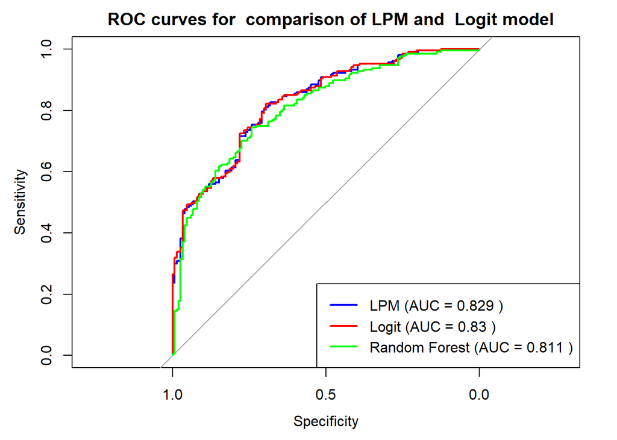

```r
 plot(roc_1,col="blue",main="  ROC curves for  comparison of LPM and  Logit model")
 lines(roc_2,col="red")
 lines(roc_3,col="green")
 # Added legend with AUC values
legend("bottomright",
       legend = c(paste("LPM (AUC =", round(auc(roc_1), 3), ")"),
                 paste("Logit (AUC =", round(auc(roc_2), 3), ")"),
                 paste("Random Forest (AUC =", round(auc(roc_3), 3), ")")),
       col = c("blue", "red", "green"),
       lwd = 2)
```

## 7-

According to the previous question our best model is the logit model whose estimation results are as follows:

```r
# Results of  logit model.
summary(lm.fit2)
```

```
##
## Call:
## glm(formula = modf2, family = "binomial", data = my_train)
##
## Coefficients:
##                          Estimate Std. Error z value Pr(>|z|)
## (Intercept)             -2.800588   0.638058  -4.389 1.14e-05 ***
## categoryBreakfast        1.953657   0.665031   2.938 0.003307 **
## categoryChicken          2.366162   0.699969   3.380 0.000724 ***
## categoryChicken Breast   2.727279   0.674938   4.041 5.33e-05 ***
## categoryDessert          3.735893   0.715308   5.223 1.76e-07 ***
## categoryLunch/Snacks     3.970579   0.697898   5.689 1.28e-08 ***
## categoryMeat             3.679784   0.695140   5.294 1.20e-07 ***
## categoryOne Dish Meal    3.907939   0.734461   5.321 1.03e-07 ***
## categoryPork             5.187866   0.876548   5.919 3.25e-09 ***
## categoryPotato           5.182113   0.803754   6.447 1.14e-10 ***
## categoryVegetable        6.576955   1.176951   5.588 2.30e-08 ***
## calories                -0.000177   0.000232  -0.763 0.445525
## protein                  0.001677   0.003749   0.447 0.654627
## sugar                   -0.006839   0.008798  -0.777 0.436975
## carbohydrate             0.002719   0.002681   1.014 0.310421
## servings2                0.086869   0.365941   0.237 0.812357
## servings4               -0.063203   0.293321  -0.215 0.829399
## servings4 as a snack    -1.054900   1.477123  -0.714 0.475129
## servings6                0.162923   0.348926   0.467 0.640553
## servings6 as a snack    12.556017 535.411357   0.023 0.981290
## ---
## Signif. codes:  0 '***' 0.001 '**' 0.01 '*' 0.05 '.' 0.1 ' ' 1
##
## (Dispersion parameter for binomial family taken to be 1)
##
##     Null deviance: 717.85  on 536  degrees of freedom
## Residual deviance: 510.51  on 517  degrees of freedom
## AIC: 550.51
##
## Number of Fisher Scoring iterations: 12
```

## Conclusion

In conclusion, only the *Category* variable, depending on its *modalities*, seems to be a good predictor of the aspect of revenue traffic on the company’s site.

## Recommendations for Increasing Site Traffic.

Based on previous results, **revenue category** is the variable that could have the greatest impact on increasing revenue traffic. We therefore make the following recommendations for an optimal traffic increase strategy:

1. **Highlight vegetable-based recipes**:
   - Vegetable-based recipes seem to be the most popular. Make sure they are easily accessible on the site.
2. **Highlight *Pork **and** Potato** recipes:
   - These two types of recipes also attract a lot of visitors, so it is crucial to give them pride of place on the site.
3. **Promote recipes from the* *Dessert** category:
   - Recipes in the *Dessert* category also attract a large number of customers. Make sure they are clearly visible and highlighted.

## Summary of Recommendations.

- **Prioritize vegetarian recipes**, particularly vegetable-based recipes, to attract more visitors.
- **Promote *Pork **and** Potato** recipes, which have great traffic potential.
- **Highlight desserts**, a category that generates strong interest from visitors.

## Estimation of different model without cancelling observation.

```r
## New importing of data base

Data1 <- read_csv("C:/Users/Users/Desktop/Projet_classification/recipe_site_traffic_2212.csv")%>%
  mutate_if(is.character, as.factor)
#Recoding of the dependent varaible
Data1$trafic_recod<-ifelse(is.na(Data1$high_traffic), 0, 1)
str(Data1$trafic_recod)
```

```
##  num [1:947] 1 1 0 1 0 1 0 0 1 0 ...
```

```r
#  Cross-validation

set.seed(2453)
tr <- sample(nrow(Data1), round(nrow(Data1) * 0.6)) ## 60/40 split train/test
my_train1 <- Data1[tr, ]
my_test1  <- Data1[-tr, ]

# Implementation of the model LPM et LOGIT.
modf1 <- trafic_recod~ category + calories + protein + sugar+ carbohydrate + servings
# Model Logit

modf2 <- trafic_recod~ category + calories + protein + sugar+ carbohydrate + servings

lm.fit11 <- lm(modf1 , data=my_train1)
lm.fit21 <-  glm(modf2 , family="binomial",data=my_train1)

stargazer(lm.fit1,lm.fit2,lm.fit11,lm.fit21,
          dep.var.caption="",dep.var.labels="",
          omit.table.layout = "n", star.cutoffs = NA,no.space=TRUE,
          keep.stat=c("rsq","n"),
          header=FALSE,
          column.labels=c("LPM ", "LOGIT","LPM with NA","LOGIT with NA"),
          title="Aspect of trafic", type="text"
          )
```

```
##
## Aspect of trafic
## ====================================================================
##
##                           OLS    logistic      OLS       logistic
##                           LPM      LOGIT   LPM with NA LOGIT with NA
##                           (1)       (2)        (3)          (4)
## --------------------------------------------------------------------
## categoryBreakfast        0.240     1.954      0.275        2.088
##                         (0.077)   (0.665)    (0.076)      (0.654)
## categoryChicken          0.332     2.366      0.321        2.309
##                         (0.090)   (0.700)    (0.093)      (0.712)
## categoryChicken Breast   0.417     2.727      0.418        2.728
##                         (0.082)   (0.675)    (0.085)      (0.683)
## categoryDessert          0.652     3.736      0.561        3.304
##                         (0.088)   (0.715)    (0.089)      (0.702)
## categoryLunch/Snacks     0.699     3.971      0.563        3.278
##                         (0.083)   (0.698)    (0.084)      (0.679)
## categoryMeat             0.640     3.680      0.748        4.226
##                         (0.085)   (0.695)    (0.092)      (0.742)
## categoryOne Dish Meal    0.688     3.908      0.719        4.058
##                         (0.092)   (0.734)    (0.089)      (0.724)
## categoryPork             0.851     5.188      0.913        5.884
##                         (0.095)   (0.877)    (0.092)      (0.970)
## categoryPotato           0.841     5.182      0.843        5.166
##                         (0.083)   (0.804)    (0.084)      (0.803)
## categoryVegetable        0.911     6.577      0.916        6.650
##                         (0.083)   (1.177)    (0.083)      (1.177)
## calories               -0.00003   -0.0002   -0.00002      -0.0002
##                        (0.00004) (0.0002)   (0.00004)    (0.0002)
## protein                 0.0003     0.002     -0.0005      -0.002
##                         (0.001)   (0.004)    (0.001)      (0.003)
## sugar                   -0.001    -0.007     -0.002       -0.011
##                         (0.002)   (0.009)    (0.001)      (0.008)
## carbohydrate            0.0003     0.003     0.0003        0.002
##                        (0.0004)   (0.003)   (0.0004)      (0.003)
## servings2                0.015     0.087     -0.038       -0.239
##                         (0.058)   (0.366)    (0.056)      (0.343)
## servings4               -0.009    -0.063     -0.027       -0.177
##                         (0.048)   (0.293)    (0.050)      (0.307)
## servings4 as a snack    -0.242    -1.055      0.391       13.173
##                         (0.295)   (1.477)    (0.412)     (535.411)
## servings6                0.026     0.163     -0.015       -0.085
##                         (0.056)   (0.349)    (0.057)      (0.350)
## servings6 as a snack     0.265    12.556
##                         (0.412)  (535.411)
## Constant                 0.067    -2.801      0.104       -2.538
##                         (0.067)   (0.638)    (0.069)      (0.635)
## --------------------------------------------------------------------
## Observations              537       537        539          539
## R2                       0.338                0.341
## ====================================================================
```